# Optimization HW_2

#### Group Members:

Joan Lee  
Chantel Miller  
Kenwan Cheung  
Tony Smaniotto

1. Consider the following LP problem:

A. Use Julia's solver to find the solution.

```julia
using JuMP
using GLPKMathProgInterface

myModel = Model(solver=GLPKSolverLP())
@variable(myModel, x1 >=0)
@variable(myModel, x2 >= 0)
@constraint(myModel, -1*x1 + x2 <= 1)
@constraint(myModel, -0.5*x1 + x2 <= 2)
@constraint(myModel, x1 + x2 <= 9)
@constraint(myModel, 0.5*x1 + x2 <= 6)
@objective(myModel, Max, x2)
myModel
```

$$ \begin{alignat*}{1}\max\quad & x2\\ \text{Subject to} \quad & -x1 + x2 \leq 1\\ & -0.5 x1 + x2 \leq 2\\ & x1 + x2 \leq 9\\ & 0.5 x1 + x2 \leq 6\\ & x1 \geq 0\\ & x2 \geq 0\\ \end{alignat*} $$

B. What is the value of the objective function evaluated at the optimal solution?

```julia
@time begin
    status=solve(myModel)
end
println("Objective value: ", getobjectivevalue(myModel))
println("x1 = ", getvalue(x1))
println("x2 = ", getvalue(x2))
```

```
  4.426443 seconds (1.42 M allocations: 52.699 MiB, 1.57% gc time)
Objective value: 4.0
x1 = 4.0
x2 = 4.0
```

C. Draw the constraints and the objective function at the optimal level.

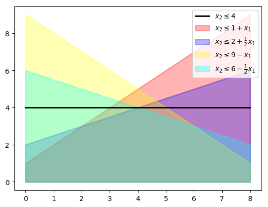

```
PyObject <matplotlib.legend.Legend object at 0x23A09FF0>
```

```julia
using PyPlot
x1 = collect(0:0.1:8)
x2a = ifelse.(1+x1.>=0,1+x1, NaN)
x2b = ifelse.(2+0.5*x1.>=0,2+0.5*x1,NaN)
x2c = ifelse.(9-x1.>=0,9-x1,NaN)
x2d = ifelse.(-0.5*x1+6.>=0,-0.5*x1+6,NaN)
x2e = ifelse.(x1.>=0, 4 ,NaN)

fig, ax = subplots()
ax[:fill_between](x1, x2a, color="red",linewidth=2,label=L"x_{2} \leq 1 + x_{1}",alpha=0.3)
ax[:legend](loc="upper right")
ax[:fill_between](x1,x2b,color="blue",linewidth=2,label=L"x_{2} \leq 2 + \frac{1}{2}x_{1}", alpha=0.3)
ax[:legend](loc="upper right")
ax[:fill_between](x1,x2c,color="yellow",linewidth=2,label=L"x_{2} \leq 9 - x_{1}", alpha=0.3)
ax[:legend](loc="upper right")
ax[:fill_between](x1,x2d,color="cyan",linewidth=2,label=L"x_{2} \leq 6 -\frac{1}{2}x_{1}", alpha=0.3)
ax[:legend](loc="upper right")
ax[:plot](x1,x2e,color="black",linewidth=2,label=L"x_{2} \leq 4", alpha=1)
ax[:legend](loc="upper right")
```

D. Justify the optimal solution

Given the linear constraints, we are trying to find the maximum feasible solution for x2, which from the solver we know occurs at x2=4. From the graph above, you can see that the optimal solution occurs at one of the corners of the polyedron, where the objective function and constraints overlap x2=4 (and x1=4), which is the solution we found using the solver.

1. Consider the following LP problem:

A. Use Julia's solver to find the solution.

```julia
myModel = Model(solver=GLPKSolverLP())
@variable(myModel, x1 >=0)
@variable(myModel, x2 >= 0)
@constraint(myModel, 2*x1 + 3*x2 <= 9)
@constraint(myModel, x1 <= 3)
@constraint(myModel, x2 <= 2)
@objective(myModel, Max,6*x1 + 4*x2)
myModel
```

$$ \begin{alignat*}{1}\max\quad & 6 x1 + 4 x2\\ \text{Subject to} \quad & 2 x1 + 3 x2 \leq 9\\ & x1 \leq 3\\ & x2 \leq 2\\ & x1 \geq 0\\ & x2 \geq 0\\ \end{alignat*} $$

B. What is the value of the objective function evaluated at the optimal solution?

```julia
@time begin
    status=solve(myModel)
end
println("Objective value: ", getobjectivevalue(myModel))
println("x1 = ", getvalue(x1))
println("x2 = ", getvalue(x2))
```

```
  1.589337 seconds (545.21 k allocations: 19.013 MiB, 1.50% gc time)
Objective value: 22.0
x1 = 3.0
x2 = 1.0
```

C. Draw the constraints and the objective function at the optimal level.

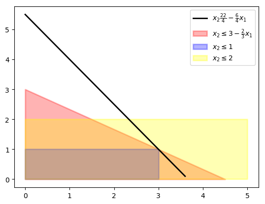

```
PyObject <matplotlib.legend.Legend object at 0x2A2FCC50>
```

```julia
using PyPlot
x1 = collect(0:0.1:5)
x2a = ifelse.(3-2/3*x1.>=0, 3-2/3*x1, NaN)
x2b = ifelse.((x1.<=3),1,NaN)
x2c = ifelse.(x1.>=0,2,NaN)
x2e = ifelse.(22/4 - 6/4*x1.>=0, 22/4 - 6/4*x1 ,NaN)

fig, ax = subplots()
ax[:fill_between](x1, x2a, color="red",linewidth=2,label=L"x_{2} \leq 3 - \frac{2}{3}x_{1}",alpha=0.3)
ax[:legend](loc="upper right")
ax[:fill_between](x1,x2b,color="blue",linewidth=2,label=L"x_{2} \leq 1", alpha=0.3)
ax[:legend](loc="upper right")
ax[:fill_between](x1,x2c,color="yellow",linewidth=2,label=L"x_{2} \leq 2", alpha=0.3)
ax[:legend](loc="upper right")
ax[:plot](x1,x2e,color="black",linewidth=2,label=L"x_{2} \frac{22}{4} - \frac{6}{4}x_{1}", alpha=1)
ax[:legend](loc="upper right")
```

D. Justify the optimal solution  
Per the solver, the value of the objective function at the optimal solution is x1=3.0, x2=1.0. From the graph above, it is evident that objective function overlaps with the polyedron at x1=3.0, x2=1.0.

1. Consider the following short-term financing problem of a corporation. The treasury deparment determined the company's net cash flow as described in the table below:

Month Jul 2013 Aug 2013 Sep 2013 Oct 2013 Nov 2013 Dec 2013 NCF -250 -50 225 -175 150 400 Notes: In thousands of dollars. NCF = Net Cash Flow

The company has two methods to conduct short-term financing. It can borrow up to $100k monthly at a 0.5% interest rate per month. It can also issue a 3-month zero-coupon bond at 1.5% for a three month period. Any available cash at the end of each month can earn 0.2% interest rate per month.

A. For each month, find the amount of borrowing between the two instruments that maximizes the total amount of cash available in December 2013.

```julia
myModel = Model(solver=GLPKSolverLP())
@variable(myModel, b1 >=0)
@variable(myModel, b2 >=0)
@variable(myModel, b3 >=0)
@variable(myModel, b4 >=0)
@variable(myModel, b5 >=0)

@variable(myModel, c1 >=0)
@variable(myModel, c2 >=0)
@variable(myModel, c3 >=0)
@variable(myModel, c4 >=0)
@variable(myModel, c5 >=0)
@variable(myModel, c6 >=0)

@variable(myModel, z1 >=0)
@variable(myModel, z2 >=0)
@variable(myModel, z3 >=0)

@constraint(myModel, b1 + z1 - c1 == 250)
@constraint(myModel, -1.005*b1 + b2 + z2 + 1.002*c1 - c2 == 50)
@constraint(myModel, -1.005*b2 + b3 + z3 + 1.002*c2 - c3 == -225)
@constraint(myModel, -1.005*b3 + b4 - 1.015*z1 + 1.002*c3 - c4 == 175)
@constraint(myModel, -1.005*b4 + b5 - 1.015*z2 + 1.002*c4 - c5 == -150)
@constraint(myModel, -1.005*b5 - 1.015*z3 + 1.002*c5 - c6 == -400)
@constraint(myModel, b1<=100)
@constraint(myModel, b2<=100)
@constraint(myModel, b3<=100)
@constraint(myModel, b4<=100)
@constraint(myModel, b5<=100)

@objective(myModel, Max, c6)
myModel
```

$$ \begin{alignat*}{1}\max\quad & c6\\ \text{Subject to} \quad & b1 + z1 - c1 = 250\\ & -1.005 b1 + b2 + z2 + 1.002 c1 - c2 = 50\\ & -1.005 b2 + b3 + z3 + 1.002 c2 - c3 = -225\\ & -1.005 b3 + b4 - 1.015 z1 + 1.002 c3 - c4 = 175\\ & -1.005 b4 + b5 - 1.015 z2 + 1.002 c4 - c5 = -150\\ & -1.005 b5 - 1.015 z3 + 1.002 c5 - c6 = -400\\ & b1 \leq 100\\ & b2 \leq 100\\ & b3 \leq 100\\ & b4 \leq 100\\ & b5 \leq 100\\ & b1 \geq 0\\ & b2 \geq 0\\ & b3 \geq 0\\ & b4 \geq 0\\ & b5 \geq 0\\ & c1 \geq 0\\ & c2 \geq 0\\ & c3 \geq 0\\ & c4 \geq 0\\ & c5 \geq 0\\ & c6 \geq 0\\ & z1 \geq 0\\ & z2 \geq 0\\ & z3 \geq 0\\ \end{alignat*} $$

```julia
@time begin
    status=solve(myModel)
end
println("Objective value: ", getobjectivevalue(myModel))
println("b1 = ", getvalue(b1))
println("b2 = ", getvalue(b2))
println("b3 = ", getvalue(b3))
println("b4 = ", getvalue(b4))
println("b5 = ", getvalue(b5))

println("c1 = ", getvalue(c1))
println("c2 = ", getvalue(c2))
println("c3 = ", getvalue(c3))
println("c4 = ", getvalue(c4))
println("c5 = ", getvalue(c5))
println("c6 = ", getvalue(c6))

println("z1 = ", getvalue(z1))
println("z2 = ", getvalue(z2))
println("z3 = ", getvalue(z3))
```

```
  0.021839 seconds (139 allocations: 8.297 KiB)
Objective value: 294.40285920658687
b1 = 100.0
b2 = 100.0
b3 = 0.0
b4 = 100.0
b5 = 1.7574999999999823
c1 = 0.0
c2 = 0.0
c3 = 226.79640718562874
c4 = 0.0
c5 = 0.0
c6 = 294.40285920658687
z1 = 150.0
z2 = 50.49999999999999
z3 = 102.29640718562874
```

Below you can see the amount of borrowing between the two instruments that maximizes the total amount of cash available in December 2013.

```julia
println("b1 = ", getvalue(b1))
println("b2 = ", getvalue(b2))
println("b3 = ", getvalue(b3))
println("b4 = ", getvalue(b4))
println("b5 = ", getvalue(b5))

println("z1 = ", getvalue(z1))
println("z2 = ", getvalue(z2))
println("z3 = ", getvalue(z3))
```

```
b1 = 100.0
b2 = 100.0
b3 = 0.0
b4 = 100.0
b5 = 1.7574999999999823
z1 = 150.0
z2 = 50.49999999999999
z3 = 102.29640718562874
```

B. What is the optimal amount of cash on Dec 2013?  
The optimal amount of cash in Dec 2013 is $294.40k.

C. Interpret the results and develop a storyline implied by the LP solution.  
According to the solution, in December 2013, the company should borrows \$1.75k, and is paying back \$103.83k on the bond it issued in September. The company would have brought in 0.2% interest on the cash it had available in November, however that amount was \$0. The company has \$294.40k available in cash in December 2013.